## BAN502 Course Project Part 1

### Kenny Buckenmeyer

```r
ames_student <- read_csv("ban-502-ames-classification-spring-2021/ames_student.csv")
summary(ames_student)
```

```
##        X1       MS_SubClass         MS_Zoning          Lot_Frontage
##  Min.   :   1   Length:2053        Length:2053        Min.   :  0.00
##  1st Qu.: 514   Class :character   Class :character   1st Qu.: 43.00
##  Median :1027   Mode  :character   Mode  :character   Median : 62.00
##  Mean   :1027                                         Mean   : 57.38
##  3rd Qu.:1540                                         3rd Qu.: 78.00
##  Max.   :2053                                         Max.   :313.00
##     Lot_Area         Street             Alley            Lot_Shape
##  Min.   :  1300   Length:2053        Length:2053        Length:2053
##  1st Qu.:  7500   Class :character   Class :character   Class :character
##  Median :  9548   Mode  :character   Mode  :character   Mode  :character
##  Mean   : 10258
##  3rd Qu.: 11600
##  Max.   :215245
##  Land_Contour        Utilities          Lot_Config         Land_Slope
##  Length:2053        Length:2053        Length:2053        Length:2053
##  Class :character   Class :character   Class :character   Class :character
##  Mode  :character   Mode  :character   Mode  :character   Mode  :character
##
##
##
##  Neighborhood       Condition_1        Condition_2         Bldg_Type
##  Length:2053        Length:2053        Length:2053        Length:2053
##  Class :character   Class :character   Class :character   Class :character
##  Mode  :character   Mode  :character   Mode  :character   Mode  :character
##
##
##
##  House_Style        Overall_Qual       Overall_Cond         Year_Built
##  Length:2053        Length:2053        Length:2053        Min.   :1875
##  Class :character   Class :character   Class :character   1st Qu.:1953
##  Mode  :character   Mode  :character   Mode  :character   Median :1972
##                                                           Mean   :1971
##                                                           3rd Qu.:2000
##                                                           Max.   :2010
##  Year_Remod_Add  Roof_Style         Roof_Matl         Exterior_1st
##  Min.   :1950   Length:2053        Length:2053        Length:2053
##  1st Qu.:1965   Class :character   Class :character   Class :character
##  Median :1993   Mode  :character   Mode  :character   Mode  :character
##  Mean   :1984
```

[output cut: 92 more lines]

```
##                                        Max.   :17000.00   Max.   :12.000
##    Year_Sold     Sale_Type         Sale_Condition       Longitude
##  Min.   :2006   Length:2053        Length:2053        Min.   :-93.69
##  1st Qu.:2007   Class :character   Class :character   1st Qu.:-93.66
##  Median :2008   Mode  :character   Mode  :character   Median :-93.64
##  Mean   :2008                                         Mean   :-93.64
##  3rd Qu.:2009                                         3rd Qu.:-93.62
##  Max.   :2010                                         Max.   :-93.58
##     Latitude     Above_Median
##  Min.   :41.99   Length:2053
##  1st Qu.:42.02   Class :character
##  Median :42.03   Mode  :character
##  Mean   :42.03
##  3rd Qu.:42.05
##  Max.   :42.06
```

```r
str(ames_student)
```

```
## tibble [2,053 x 82] (S3: spec_tbl_df/tbl_df/tbl/data.frame)
##  $ X1                : num [1:2053] 1 2 3 4 5 6 7 8 9 10 ...
##  $ MS_SubClass       : chr [1:2053] "One_Story_1946_and_Newer_All_Styles" "One_Story_1946_and_Newer_All_Styles" "One_Story_1946_and_Newer_All_Styles" "One_Story_1946_and_Newer_All_Styles" ...
##  $ MS_Zoning         : chr [1:2053] "Residential_Low_Density" "Residential_High_Density" "Residential_Low_Density" "Residential_Low_Density" ...
##  $ Lot_Frontage      : num [1:2053] 141 80 81 93 74 78 43 39 0 85 ...
##  $ Lot_Area          : num [1:2053] 31770 11622 14267 11160 13830 ...
##  $ Street            : chr [1:2053] "Pave" "Pave" "Pave" "Pave" ...
##  $ Alley             : chr [1:2053] "No_Alley_Access" "No_Alley_Access" "No_Alley_Access" "No_Alley_Access" ...
##  $ Lot_Shape         : chr [1:2053] "Slightly_Irregular" "Regular" "Slightly_Irregular" "Regular" ...
##  $ Land_Contour      : chr [1:2053] "Lvl" "Lvl" "Lvl" "Lvl" ...
##  $ Utilities         : chr [1:2053] "AllPub" "AllPub" "AllPub" "AllPub" ...
##  $ Lot_Config        : chr [1:2053] "Corner" "Inside" "Corner" "Corner" ...
##  $ Land_Slope        : chr [1:2053] "Gtl" "Gtl" "Gtl" "Gtl" ...
##  $ Neighborhood      : chr [1:2053] "North_Ames" "North_Ames" "North_Ames" "North_Ames" ...
##  $ Condition_1       : chr [1:2053] "Norm" "Feedr" "Norm" "Norm" ...
##  $ Condition_2       : chr [1:2053] "Norm" "Norm" "Norm" "Norm" ...
##  $ Bldg_Type         : chr [1:2053] "OneFam" "OneFam" "OneFam" "OneFam" ...
##  $ House_Style       : chr [1:2053] "One_Story" "One_Story" "One_Story" "One_Story" ...
##  $ Overall_Qual      : chr [1:2053] "Above_Average" "Average" "Above_Average" "Good" ...
##  $ Overall_Cond      : chr [1:2053] "Average" "Above_Average" "Above_Average" "Average" ...
##  $ Year_Built        : num [1:2053] 1960 1961 1958 1968 1997 ...
##  $ Year_Remod_Add    : num [1:2053] 1960 1961 1958 1968 1998 ...
##  $ Roof_Style        : chr [1:2053] "Hip" "Gable" "Hip" "Hip" ...
##  $ Roof_Matl         : chr [1:2053] "CompShg" "CompShg" "CompShg" "CompShg" ...
##  $ Exterior_1st      : chr [1:2053] "BrkFace" "VinylSd" "Wd Sdng" "BrkFace" ...
##  $ Exterior_2nd      : chr [1:2053] "Plywood" "VinylSd" "Wd Sdng" "BrkFace" ...
##  $ Mas_Vnr_Type      : chr [1:2053] "Stone" "None" "BrkFace" "None" ...
##  $ Mas_Vnr_Area      : num [1:2053] 112 0 108 0 0 20 0 0 0 0 ...
##  $ Exter_Qual        : chr [1:2053] "Typical" "Typical" "Typical" "Good" ...
##  $ Exter_Cond        : chr [1:2053] "Typical" "Typical" "Typical" "Typical" ...
##  $ Foundation        : chr [1:2053] "CBlock" "CBlock" "CBlock" "CBlock" ...
##  $ Bsmt_Qual         : chr [1:2053] "Typical" "Typical" "Typical" "Typical" ...
##  $ Bsmt_Cond         : chr [1:2053] "Good" "Typical" "Typical" "Typical" ...
##  $ Bsmt_Exposure     : chr [1:2053] "Gd" "No" "No" "No" ...
##  $ BsmtFin_Type_1    : chr [1:2053] "BLQ" "Rec" "ALQ" "ALQ" ...
##  $ BsmtFin_SF_1      : num [1:2053] 2 6 1 1 3 3 1 3 1 3 ...
##  $ BsmtFin_Type_2    : chr [1:2053] "Unf" "LwQ" "Unf" "Unf" ...
##  $ BsmtFin_SF_2      : num [1:2053] 0 144 0 0 0 0 0 0 0 0 ...
##  $ Bsmt_Unf_SF       : num [1:2053] 441 270 406 1045 137 ...
##  $ Total_Bsmt_SF     : num [1:2053] 1080 882 1329 2110 928 ...
```

[output cut: 113 more lines]

```
##   ..   Three_season_porch = col_double(),
##   ..   Screen_Porch = col_double(),
##   ..   Pool_Area = col_double(),
##   ..   Pool_QC = col_character(),
##   ..   Fence = col_character(),
##   ..   Misc_Feature = col_character(),
##   ..   Misc_Val = col_double(),
##   ..   Mo_Sold = col_double(),
##   ..   Year_Sold = col_double(),
##   ..   Sale_Type = col_character(),
##   ..   Sale_Condition = col_character(),
##   ..   Longitude = col_double(),
##   ..   Latitude = col_double(),
##   ..   Above_Median = col_character()
##   .. )
```

```r
ames_student <- ames_student %>% mutate_if(is.character, as_factor)
```

```r
colorpal <- colorFactor(palette = "RdYlBu", ames_student$Above_Median)
```

```r
ames_map <- leaflet() %>% setView(lng = -93.64, lat = 42.02, zoom = 12) %>%
  addTiles() %>%
  addCircleMarkers(data = ames_student, lng = ~Longitude, lat = ~Latitude, weight = 1.5, radius = 1, color = ~colorpal(Above_Median)) %>%
  addLegend(data = ames_student, position = "bottomright", pal = colorpal, values = ~Above_Median)

ames_map
```

[interactive chart not shown]

This map provides a visualization comparing the houses that sold above the median price and the houses that sold below the median price. There is noticeable difference among the houses north of Iowa State University. The houses west and northwest of Parkview Heights typically sold above the median price, while the houses east and southeast of Parkview Heights typically sold below the median price.

```r
ames_student$X1 <- NULL
ames_student <- ames_student %>% relocate(Above_Median, .before = MS_SubClass)
head(ames_student)
```

```
## # A tibble: 6 x 81
##   Above_Median MS_SubClass MS_Zoning Lot_Frontage Lot_Area Street Alley
##   <fct>        <fct>       <fct>            <dbl>    <dbl> <fct>  <fct>
## 1 Yes          One_Story_~ Resident~          141    31770 Pave   No_A~
## 2 No           One_Story_~ Resident~           80    11622 Pave   No_A~
## 3 Yes          One_Story_~ Resident~           81    14267 Pave   No_A~
## 4 Yes          One_Story_~ Resident~           93    11160 Pave   No_A~
## 5 Yes          Two_Story_~ Resident~           74    13830 Pave   No_A~
## 6 Yes          Two_Story_~ Resident~           78     9978 Pave   No_A~
## # ... with 74 more variables: Lot_Shape <fct>, Land_Contour <fct>,
## #   Utilities <fct>, Lot_Config <fct>, Land_Slope <fct>, Neighborhood <fct>,
## #   Condition_1 <fct>, Condition_2 <fct>, Bldg_Type <fct>, House_Style <fct>,
## #   Overall_Qual <fct>, Overall_Cond <fct>, Year_Built <dbl>,
## #   Year_Remod_Add <dbl>, Roof_Style <fct>, Roof_Matl <fct>,
## #   Exterior_1st <fct>, Exterior_2nd <fct>, Mas_Vnr_Type <fct>,
## #   Mas_Vnr_Area <dbl>, Exter_Qual <fct>, Exter_Cond <fct>, Foundation <fct>,
## #   Bsmt_Qual <fct>, Bsmt_Cond <fct>, Bsmt_Exposure <fct>,
## #   BsmtFin_Type_1 <fct>, BsmtFin_SF_1 <dbl>, BsmtFin_Type_2 <fct>,
## #   BsmtFin_SF_2 <dbl>, Bsmt_Unf_SF <dbl>, Total_Bsmt_SF <dbl>, Heating <fct>,
## #   Heating_QC <fct>, Central_Air <fct>, Electrical <fct>, First_Flr_SF <dbl>,
## #   Second_Flr_SF <dbl>, Low_Qual_Fin_SF <dbl>, Gr_Liv_Area <dbl>,
## #   Bsmt_Full_Bath <dbl>, Bsmt_Half_Bath <dbl>, Full_Bath <dbl>,
## #   Half_Bath <dbl>, Bedroom_AbvGr <dbl>, Kitchen_AbvGr <dbl>,
## #   Kitchen_Qual <fct>, TotRms_AbvGrd <dbl>, Functional <fct>,
## #   Fireplaces <dbl>, Fireplace_Qu <fct>, Garage_Type <fct>,
## #   Garage_Finish <fct>, Garage_Cars <dbl>, Garage_Area <dbl>,
## #   Garage_Qual <fct>, Garage_Cond <fct>, Paved_Drive <fct>,
## #   Wood_Deck_SF <dbl>, Open_Porch_SF <dbl>, Enclosed_Porch <dbl>,
## #   Three_season_porch <dbl>, Screen_Porch <dbl>, Pool_Area <dbl>,
## #   Pool_QC <fct>, Fence <fct>, Misc_Feature <fct>, Misc_Val <dbl>,
## #   Mo_Sold <dbl>, Year_Sold <dbl>, Sale_Type <fct>, Sale_Condition <fct>,
## #   Longitude <dbl>, Latitude <dbl>
```

```r
ames_student %>% count(Above_Median)
```

```
## # A tibble: 2 x 2
##   Above_Median     n
##   <fct>        <int>
## 1 Yes           1043
## 2 No            1010
```

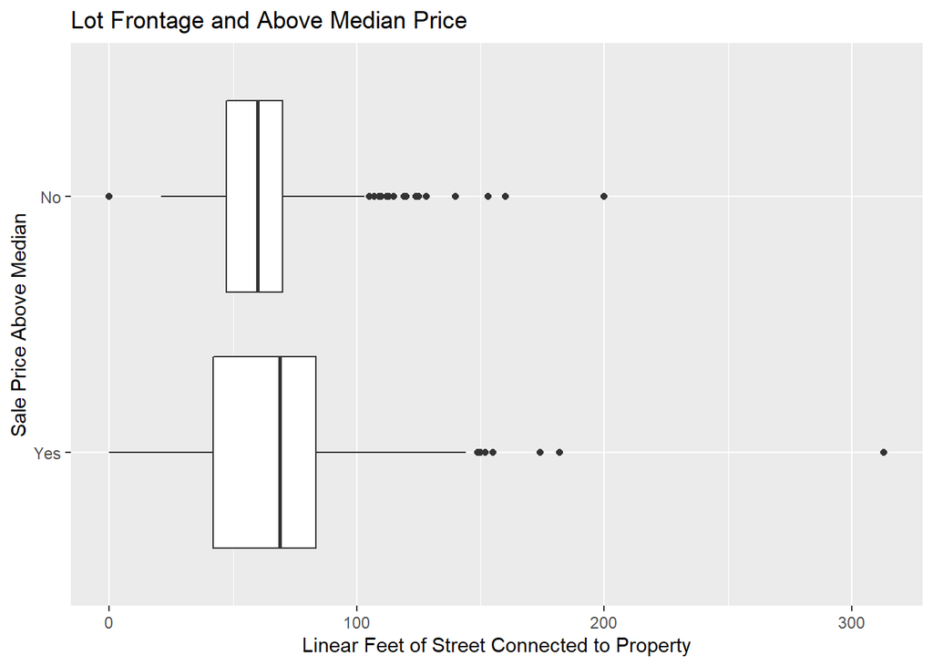

```r
ggplot(ames_student, aes(x = Lot_Frontage, y = Above_Median)) +
  geom_boxplot() +
  labs(title = "Lot Frontage and Above Median Price",
       x = "Linear Feet of Street Connected to Property",
       y = "Sale Price Above Median")
```

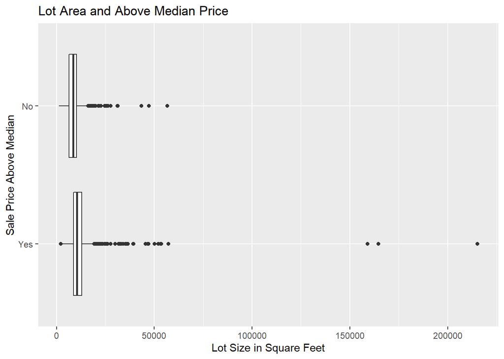

```r
ggplot(ames_student, aes(x = Lot_Area, y = Above_Median)) +
  geom_boxplot() +
  labs(title = "Lot Area and Above Median Price",
       x = "Lot Size in Square Feet",
       y = "Sale Price Above Median")
```

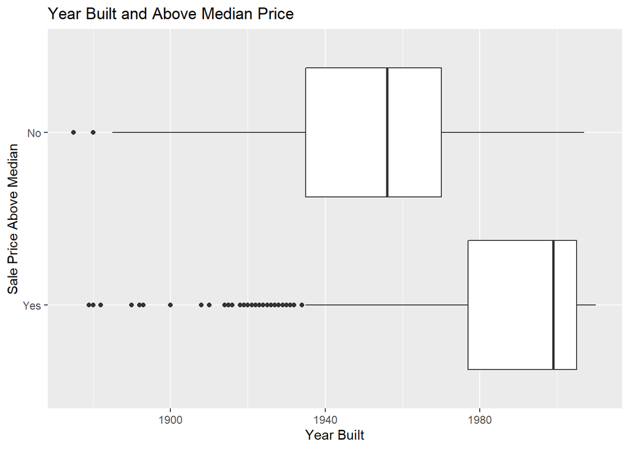

```r
ggplot(ames_student, aes(x = Year_Built, y = Above_Median)) +
  geom_boxplot() +
  labs(title = "Year Built and Above Median Price",
       x = "Year Built",
       y = "Sale Price Above Median")
```

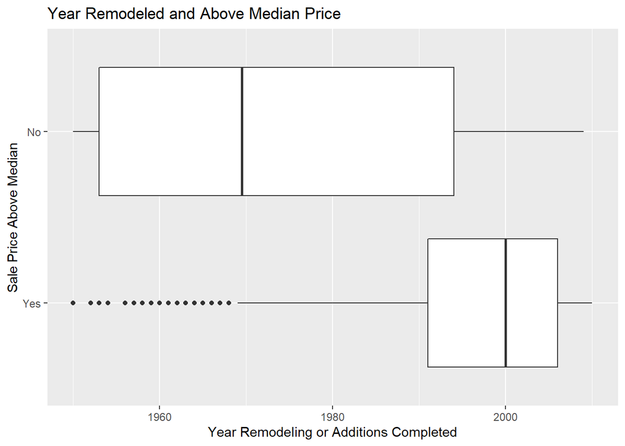

```r
ggplot(ames_student, aes(x = Year_Remod_Add, y = Above_Median)) +
  geom_boxplot() +
  labs(title = "Year Remodeled and Above Median Price",
       x= "Year Remodeling or Additions Completed",
       y = "Sale Price Above Median")
```

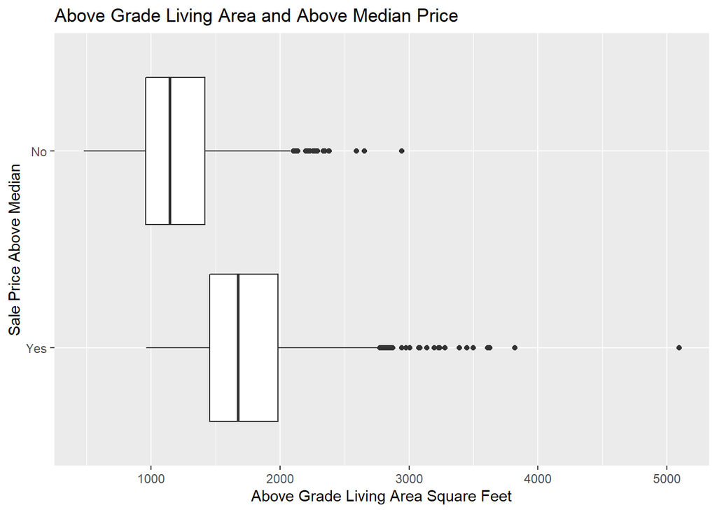

```r
ggplot(ames_student, aes(x = Gr_Liv_Area, y = Above_Median)) +
  geom_boxplot() +
  labs(title = "Above Grade Living Area and Above Median Price",
       x = "Above Grade Living Area Square Feet",
       y = "Sale Price Above Median")
```

The above plots compared five numeric variables (Lot_Frontage, Lot_Area, Year_Built, Year_Remod_Add, Gr_Liv_Area). There isn’t a significant difference between the houses that sold above and below the median price when looking at the total linear square feet of street connected to the property. Surprisingly, there isn’t a significant difference between the houses that sold above and below the median price when looking at total lot size. There is a significant difference when looking at the year the house was built. While the houses that sold above the median price have more variance, the mean of these houses is significantly higher than the houses that did not sell above the median price. Houses with more recent remodeling or additions sold above the median price more often than houses with older remodeling or additions. Not surprisingly, houses with more above ground living area sold above the median price.

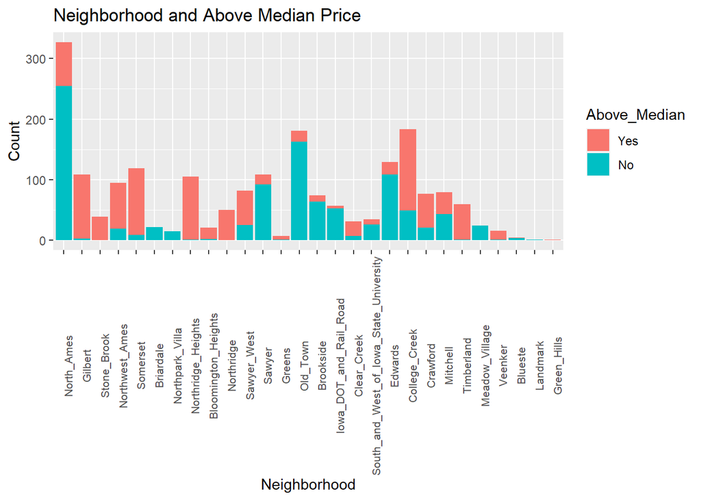

```r
ggplot(ames_student, aes(x = Neighborhood, fill = Above_Median)) +
  geom_bar() + theme(axis.text.x = element_text(size = 8, angle = 90)) +
  labs(title = "Neighborhood and Above Median Price",
       y = "Count")
```

The above visualization compares whether or not houses sold above the median price and the neighborhoods in which the houses were located. A few neighborhoods stand out that have houses selling above the median price, including Gilbert, Stone Brook, Northwest Ames, Somerset, Northridge Heights, Northridge, Sawyer West, College Creek, Crawford, and Timberland.

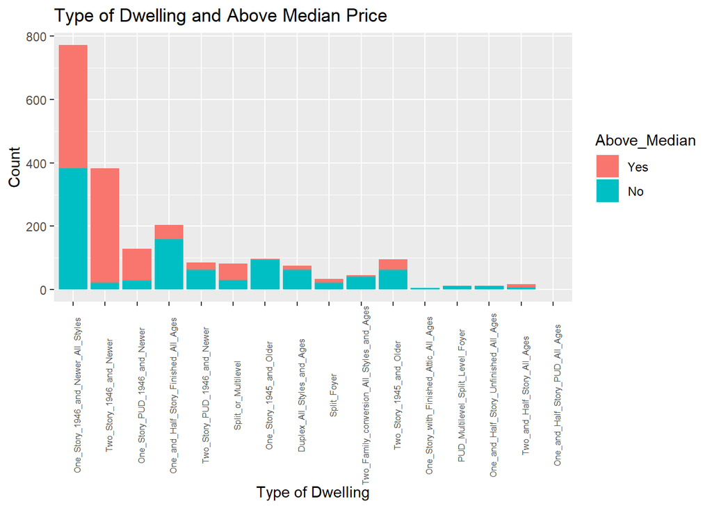

```r
ggplot(ames_student, aes(x = MS_SubClass, fill = Above_Median)) +
  geom_bar() + theme(axis.text.x = element_text(size = 6, angle = 90)) +
  labs(title = "Type of Dwelling and Above Median Price",
       x = "Type of Dwelling",
       y = "Count")
```

The above visualization compares whether or not houses sold above the median price and the type of dwelling. Two types of dwellings stand out that have houses selling above the median price, including two story houses built after 1945 and one store planned unit developments built after 1945.

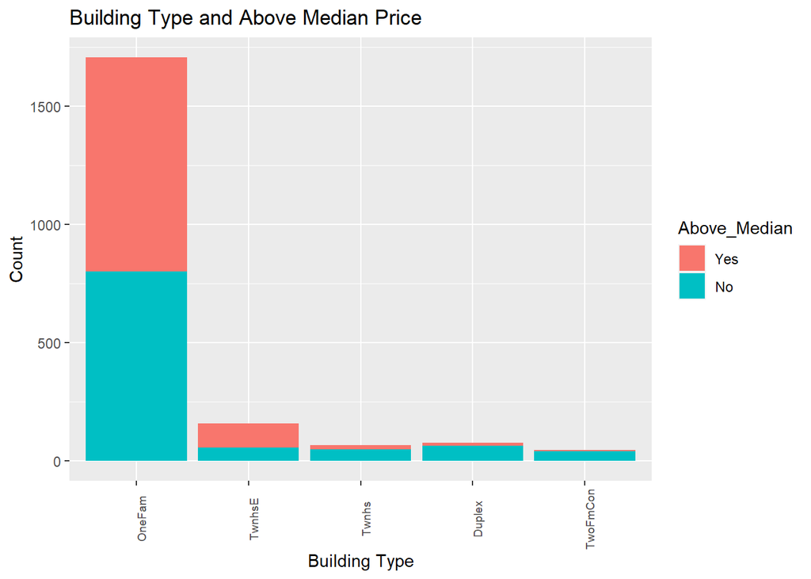

```r
ggplot(ames_student, aes(x = Bldg_Type, fill = Above_Median)) +
  geom_bar() + theme(axis.text.x = element_text(size = 7, angle = 90)) +
  labs(title = "Building Type and Above Median Price",
       x = "Building Type",
       y = "Count")
```

The above visualization compares whether or not houses sold above the median price and the building type. Three building types stand out that have houses not selling above the median price, including townhouses inside units, duplexes, and two family conversions from previous single family housing.

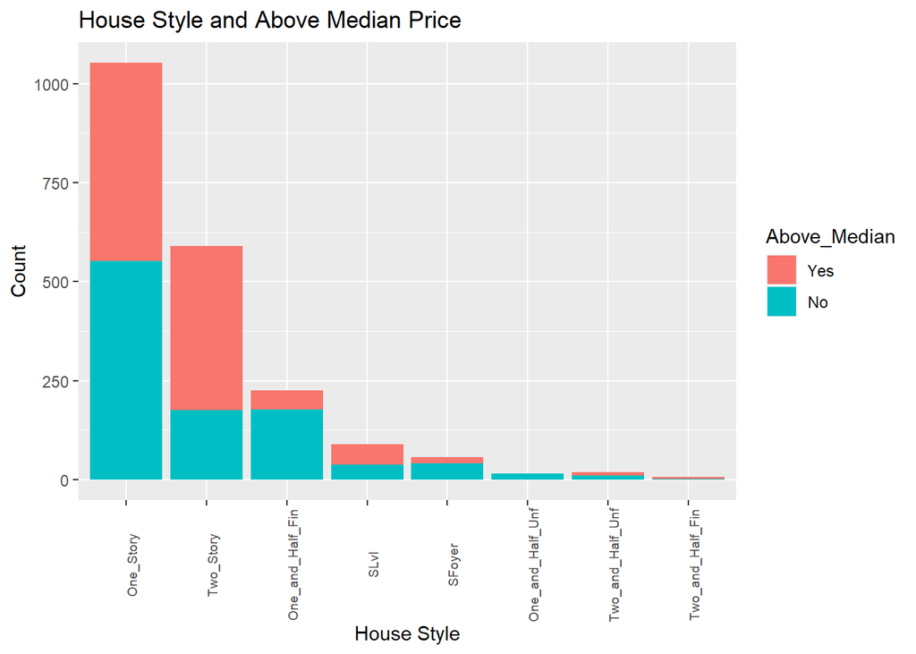

```r
ggplot(ames_student, aes(x = House_Style, fill = Above_Median)) +
  geom_bar() + theme(axis.text.x = element_text(size = 7, angle = 90)) +
  labs(title = "House Style and Above Median Price",
       x = "House Style",
       y = "Count")
```

The above visualization compares whether or not houses sold above the median price and the house style. One style stands out that have houses selling above the median price, which is two story houses.

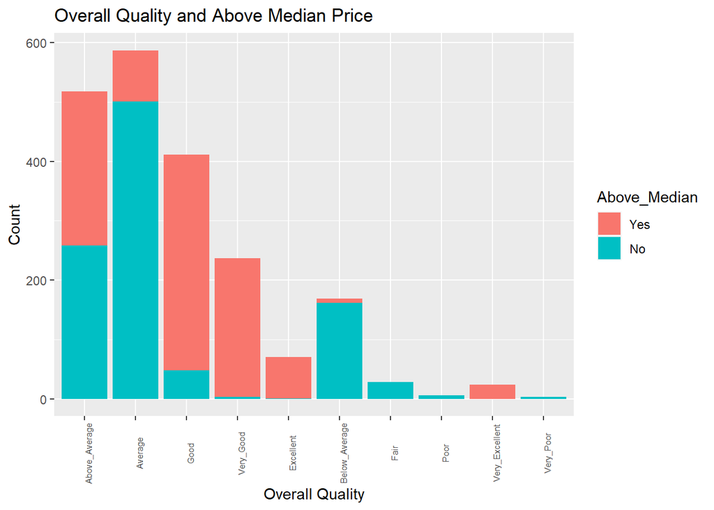

```r
ggplot(ames_student, aes(x = Overall_Qual, fill = Above_Median)) +
  geom_bar() + theme(axis.text.x = element_text(size = 6, angle = 90)) +
  labs(title = "Overall Quality and Above Median Price",
       x = "Overall Quality",
       y = "Count")
```

The above visualization compares whether or not houses sold above the median price and the overall quality. The overall quality rates the overall material and finish of the house. A few categories stand out that have houses selling above the median price, including Good, Very Good, Excellent, and Very Excellent.

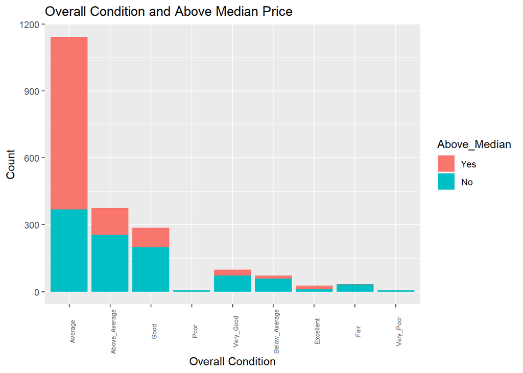

```r
ggplot(ames_student, aes(x = Overall_Cond, fill = Above_Median)) +
  geom_bar() + theme(axis.text.x = element_text(size = 6, angle = 90)) +
  labs(title = "Overall Condition and Above Median Price",
       x = "Overall Condition",
       y = "Count")
```

The above visualization compares whether or not houses sold above the median price and the overall condition of the house. Surprisingly, only the Average Overall Condition shows a significant increase in the number of houses selling above the median price.